# R Coding for Data Analysis Final Project

Joyce Zhou

08/12/2024

```r
setwd("/Users/yojozho/Desktop/BMIN-GA1005/final_project/final-assignment-yojozho")
```

# Background / Context

Breast cancer data set from Kaggle and can also be found on the UC Irvine Machine Learning Repository. The features describe the cell nuclei and were calculated from FNA breast mass images.

Link: https://www.kaggle.com/datasets/uciml/breast-cancer-wisconsin-data

The data set contains 569 observations and there are 32 variables. Contains 357 benign tumor observations and 212 malignant tumor observations. One of the variables contains IDs, another variable dictates benign and malignant tumors, and the rest of the features are measurements from the image data.

This data set allows for data visualization, heatmap generation, statistical analysis, and regression analysis

The ultimate goal is to understand the differences between benign and malignant tumors by exploring the data.

# Methods & Results

#### Import Data from .csv:

Changed `diagnosis` to a factor rather than a character variable and changed the labels to Benign and Malignant.

Subset data to only include mean measurements since they are the most important measurements.

No missing values.

```r
breast_cancer_data = read.csv("data.csv")

breast_cancer_data$diagnosis = as.factor(breast_cancer_data$diagnosis)
levels(breast_cancer_data$diagnosis) = c("Benign", "Malignant")

summary(breast_cancer_data)
```

```
##        id                diagnosis    radius_mean      texture_mean
##  Min.   :     8670   Benign   :357   Min.   : 6.981   Min.   : 9.71
##  1st Qu.:   869218   Malignant:212   1st Qu.:11.700   1st Qu.:16.17
##  Median :   906024                   Median :13.370   Median :18.84
##  Mean   : 30371831                   Mean   :14.127   Mean   :19.29
##  3rd Qu.:  8813129                   3rd Qu.:15.780   3rd Qu.:21.80
##  Max.   :911320502                   Max.   :28.110   Max.   :39.28
##  perimeter_mean     area_mean      smoothness_mean   compactness_mean
##  Min.   : 43.79   Min.   : 143.5   Min.   :0.05263   Min.   :0.01938
##  1st Qu.: 75.17   1st Qu.: 420.3   1st Qu.:0.08637   1st Qu.:0.06492
##  Median : 86.24   Median : 551.1   Median :0.09587   Median :0.09263
##  Mean   : 91.97   Mean   : 654.9   Mean   :0.09636   Mean   :0.10434
##  3rd Qu.:104.10   3rd Qu.: 782.7   3rd Qu.:0.10530   3rd Qu.:0.13040
##  Max.   :188.50   Max.   :2501.0   Max.   :0.16340   Max.   :0.34540
##  concavity_mean    concave.points_mean symmetry_mean    fractal_dimension_mean
##  Min.   :0.00000   Min.   :0.00000     Min.   :0.1060   Min.   :0.04996
##  1st Qu.:0.02956   1st Qu.:0.02031     1st Qu.:0.1619   1st Qu.:0.05770
##  Median :0.06154   Median :0.03350     Median :0.1792   Median :0.06154
##  Mean   :0.08880   Mean   :0.04892     Mean   :0.1812   Mean   :0.06280
##  3rd Qu.:0.13070   3rd Qu.:0.07400     3rd Qu.:0.1957   3rd Qu.:0.06612
##  Max.   :0.42680   Max.   :0.20120     Max.   :0.3040   Max.   :0.09744
##    radius_se        texture_se      perimeter_se       area_se
##  Min.   :0.1115   Min.   :0.3602   Min.   : 0.757   Min.   :  6.802
##  1st Qu.:0.2324   1st Qu.:0.8339   1st Qu.: 1.606   1st Qu.: 17.850
##  Median :0.3242   Median :1.1080   Median : 2.287   Median : 24.530
##  Mean   :0.4052   Mean   :1.2169   Mean   : 2.866   Mean   : 40.337
##  3rd Qu.:0.4789   3rd Qu.:1.4740   3rd Qu.: 3.357   3rd Qu.: 45.190
##  Max.   :2.8730   Max.   :4.8850   Max.   :21.980   Max.   :542.200
##  smoothness_se      compactness_se      concavity_se     concave.points_se
##  Min.   :0.001713   Min.   :0.002252   Min.   :0.00000   Min.   :0.000000
##  1st Qu.:0.005169   1st Qu.:0.013080   1st Qu.:0.01509   1st Qu.:0.007638
##  Median :0.006380   Median :0.020450   Median :0.02589   Median :0.010930
##  Mean   :0.007041   Mean   :0.025478   Mean   :0.03189   Mean   :0.011796
##  3rd Qu.:0.008146   3rd Qu.:0.032450   3rd Qu.:0.04205   3rd Qu.:0.014710
##  Max.   :0.031130   Max.   :0.135400   Max.   :0.39600   Max.   :0.052790
##   symmetry_se       fractal_dimension_se  radius_worst   texture_worst
##  Min.   :0.007882   Min.   :0.0008948    Min.   : 7.93   Min.   :12.02
##  1st Qu.:0.015160   1st Qu.:0.0022480    1st Qu.:13.01   1st Qu.:21.08
##  Median :0.018730   Median :0.0031870    Median :14.97   Median :25.41
##  Mean   :0.020542   Mean   :0.0037949    Mean   :16.27   Mean   :25.68
##  3rd Qu.:0.023480   3rd Qu.:0.0045580    3rd Qu.:18.79   3rd Qu.:29.72
##  Max.   :0.078950   Max.   :0.0298400    Max.   :36.04   Max.   :49.54
##  perimeter_worst    area_worst     smoothness_worst  compactness_worst
##  Min.   : 50.41   Min.   : 185.2   Min.   :0.07117   Min.   :0.02729
##  1st Qu.: 84.11   1st Qu.: 515.3   1st Qu.:0.11660   1st Qu.:0.14720
##  Median : 97.66   Median : 686.5   Median :0.13130   Median :0.21190
##  Mean   :107.26   Mean   : 880.6   Mean   :0.13237   Mean   :0.25427
##  3rd Qu.:125.40   3rd Qu.:1084.0   3rd Qu.:0.14600   3rd Qu.:0.33910
##  Max.   :251.20   Max.   :4254.0   Max.   :0.22260   Max.   :1.05800
##  concavity_worst  concave.points_worst symmetry_worst   fractal_dimension_worst
##  Min.   :0.0000   Min.   :0.00000      Min.   :0.1565   Min.   :0.05504
##  1st Qu.:0.1145   1st Qu.:0.06493      1st Qu.:0.2504   1st Qu.:0.07146
##  Median :0.2267   Median :0.09993      Median :0.2822   Median :0.08004
##  Mean   :0.2722   Mean   :0.11461      Mean   :0.2901   Mean   :0.08395
##  3rd Qu.:0.3829   3rd Qu.:0.16140      3rd Qu.:0.3179   3rd Qu.:0.09208
##  Max.   :1.2520   Max.   :0.29100      Max.   :0.6638   Max.   :0.20750
```

#### Subsetting:

Subset the data to only include the mean measurements since they are the most important. Remove `id` column since it’s not important to the analysis.

Then, subset the data into benign and malignant data to analyze the difference between the two categories.

```r
breast_cancer_data = breast_cancer_data[,2:12]

benign_data = grep("Benign", breast_cancer_data$diagnosis)
benign_data = breast_cancer_data[benign_data,]
malignant_data = grep("Malignant", breast_cancer_data$diagnosis)
malignant_data = breast_cancer_data[malignant_data,]
```

#### Data Visualization:

Create histogram plots to look at the distribution of the data and if it’s normally distributed.

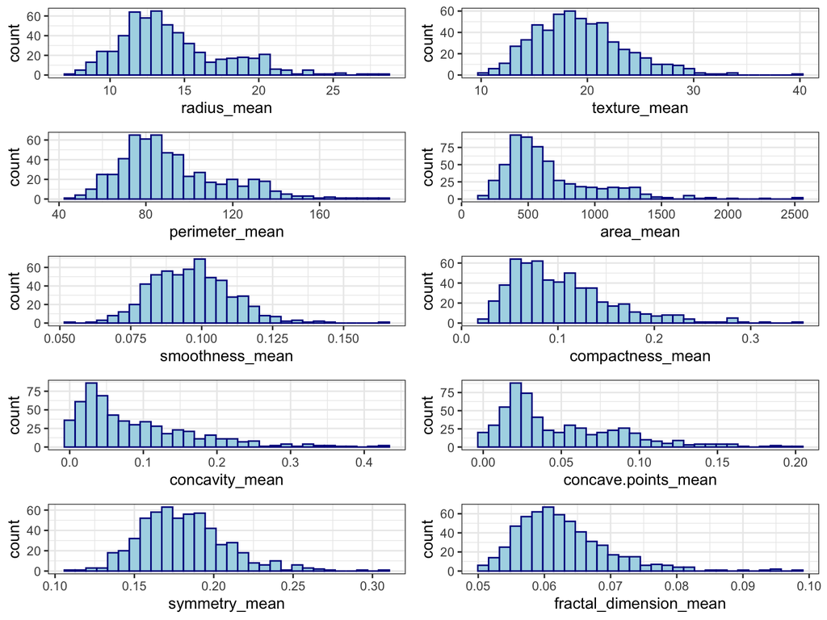

```r
p1 = ggplot(breast_cancer_data,aes(x=radius_mean),color = blue) + geom_histogram(bins = 30, color = "darkblue", fill = "lightblue") + theme_bw()
p2 = ggplot(breast_cancer_data,aes(x=texture_mean),color = blue) + geom_histogram(bins = 30, color = "darkblue", fill = "lightblue") + theme_bw()
p3 = ggplot(breast_cancer_data,aes(x=perimeter_mean),color = blue) + geom_histogram(bins = 30, color = "darkblue", fill = "lightblue") + theme_bw()
p4 = ggplot(breast_cancer_data,aes(x=area_mean),color = blue) + geom_histogram(bins = 30, color = "darkblue", fill = "lightblue") + theme_bw()
p5 = ggplot(breast_cancer_data,aes(x=smoothness_mean),color = blue) + geom_histogram(bins = 30, color = "darkblue", fill = "lightblue") + theme_bw()
p6 = ggplot(breast_cancer_data,aes(x=compactness_mean),color = blue) + geom_histogram(bins = 30, color = "darkblue", fill = "lightblue") + theme_bw()
p7 = ggplot(breast_cancer_data,aes(x=concavity_mean),color = blue) + geom_histogram(bins = 30, color = "darkblue", fill = "lightblue") + theme_bw()
p8 = ggplot(breast_cancer_data,aes(x=concave.points_mean),color = blue) + geom_histogram(bins = 30, color = "darkblue", fill = "lightblue") + theme_bw()
p9 = ggplot(breast_cancer_data,aes(x=symmetry_mean),color = blue) + geom_histogram(bins = 30, color = "darkblue", fill = "lightblue") + theme_bw()
p10 = ggplot(breast_cancer_data,aes(x=fractal_dimension_mean),color = blue) + geom_histogram(bins = 30, color = "darkblue", fill = "lightblue") + theme_bw()
ggarrange(p1, p2, p3, p4, p5, p6, p7, p8, p9, p10, ncol = 2, nrow = 5)
```

From the plots, we can see that most of the variables are skewed to the right. This could cause some issues for us down the line with our regresion model so we need to address this skewness.

#### Log Transformation:

To address skewness, we log transform the data. This brings the data closer to normal distribution

```r
breast_cancer_data[,2:11] = log(breast_cancer_data[,2:11])
breast_cancer_data[breast_cancer_data == "-Inf" ] = NA
breast_cancer_data = na.omit(breast_cancer_data)

benign_data[,2:11] = log(benign_data[,2:11])
benign_data[benign_data == "-Inf" ] = NA
benign_data = na.omit(benign_data)

malignant_data[,2:11] = log(malignant_data[,2:11])
malignant_data[malignant_data == "-Inf" ] = NA
malignant_data = na.omit(malignant_data)
```

Replot the data to check the distribution.

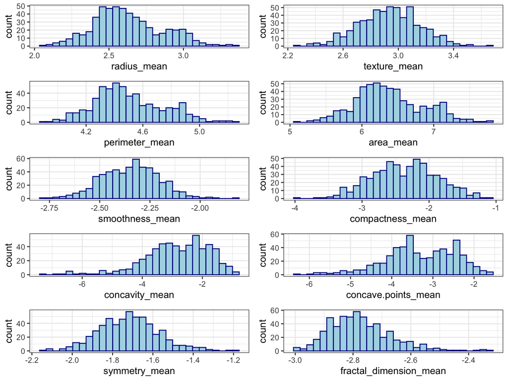

```r
p1 = ggplot(breast_cancer_data,aes(x=radius_mean),color = blue) + geom_histogram(bins = 30, color = "darkblue", fill = "lightblue") + theme_bw()
p2 = ggplot(breast_cancer_data,aes(x=texture_mean),color = blue) + geom_histogram(bins = 30, color = "darkblue", fill = "lightblue") + theme_bw()
p3 = ggplot(breast_cancer_data,aes(x=perimeter_mean),color = blue) + geom_histogram(bins = 30, color = "darkblue", fill = "lightblue") + theme_bw()
p4 = ggplot(breast_cancer_data,aes(x=area_mean),color = blue) + geom_histogram(bins = 30, color = "darkblue", fill = "lightblue") + theme_bw()
p5 = ggplot(breast_cancer_data,aes(x=smoothness_mean),color = blue) + geom_histogram(bins = 30, color = "darkblue", fill = "lightblue") + theme_bw()
p6 = ggplot(breast_cancer_data,aes(x=compactness_mean),color = blue) + geom_histogram(bins = 30, color = "darkblue", fill = "lightblue") + theme_bw()
p7 = ggplot(breast_cancer_data,aes(x=concavity_mean),color = blue) + geom_histogram(bins = 30, color = "darkblue", fill = "lightblue") + theme_bw()
p8 = ggplot(breast_cancer_data,aes(x=concave.points_mean),color = blue) + geom_histogram(bins = 30, color = "darkblue", fill = "lightblue") + theme_bw()
p9 = ggplot(breast_cancer_data,aes(x=symmetry_mean),color = blue) + geom_histogram(bins = 30, color = "darkblue", fill = "lightblue") + theme_bw()
p10 = ggplot(breast_cancer_data,aes(x=fractal_dimension_mean),color = blue) + geom_histogram(bins = 30, color = "darkblue", fill = "lightblue") + theme_bw()
ggarrange(p1, p2, p3, p4, p5, p6, p7, p8, p9, p10, ncol = 2, nrow = 5)
```

The data is less skewed after log transformation.

# Box plots:

There are 10 features but we will explore four of them for simplicity: `radius_mean`, `texture_mean`, `smoothness_mean`, and `symmetry_mean`. Create boxplots to see if there are differences in the distribution of data between benign and malignant tumors.

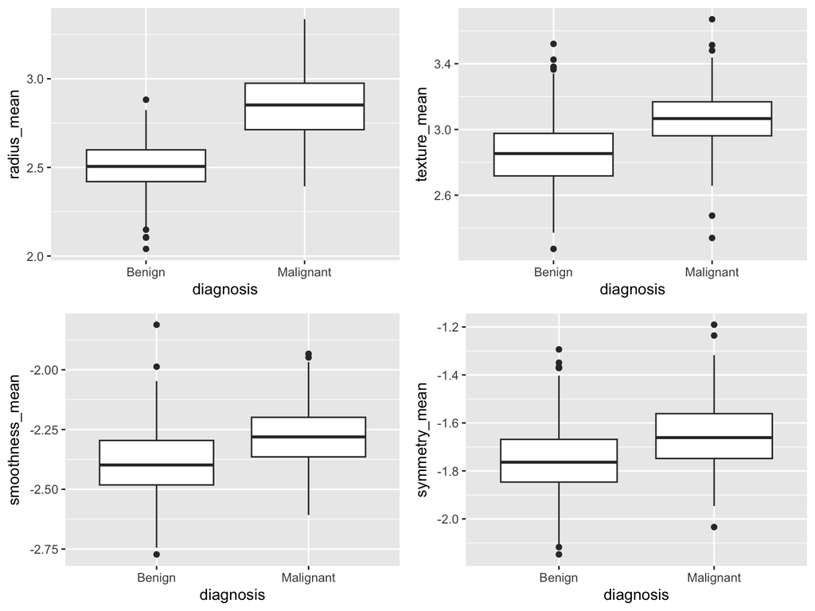

```r
b1 = ggplot(breast_cancer_data, aes(x = diagnosis, y = radius_mean)) + geom_boxplot()
b2 = ggplot(breast_cancer_data, aes(x = diagnosis, y = texture_mean)) + geom_boxplot()
b3 = ggplot(breast_cancer_data, aes(x = diagnosis, y = smoothness_mean)) + geom_boxplot()
b4 = ggplot(breast_cancer_data, aes(x = diagnosis, y = symmetry_mean)) + geom_boxplot()
ggarrange(b1, b2, b3, b4, ncol = 2, nrow = 2)
```

There is a difference in the distribution of data between benign and malignant tumors. Benign tumors generally have lower measurements than malignant tumors. This is most apparent in `radius_mean`. The data seems well suited for a classification model.

#### Heatmap:

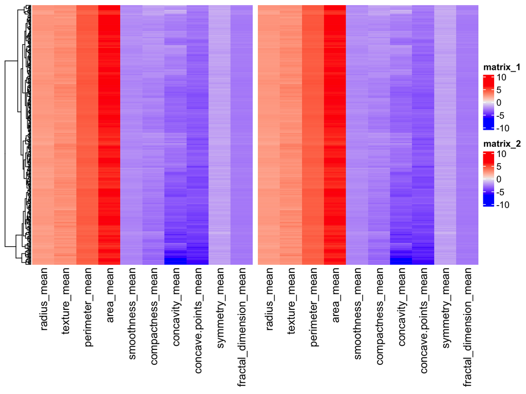

```r
benign_matrix = as.matrix(benign_data[,2:11])
malignant_matrix = as.matrix(benign_data[,2:11])

h1 = Heatmap(benign_matrix, cluster_columns = FALSE, clustering_method_rows = "complete", show_row_names = FALSE)
h2 = Heatmap(malignant_matrix, cluster_columns = FALSE, clustering_method_rows = "complete", show_row_names = FALSE)

h1 + h2
```

#### Statistical Analysis:

The relationship between the features and the `diagnosis` is nonlinear so it wouldn’t be appropriate to use a test like pearson or a test like spearman that needs two continuous variables. We will use the Mann-Whitney U test with a p-value threshold of p-value < 0.05 since that is the standard threshold.

Check if there is a relationship between `radius_mean` and `diagnosis`.

```r
wilcox.test(breast_cancer_data$radius_mean ~ breast_cancer_data$diagnosis)
```

```
##
##  Wilcoxon rank sum test with continuity correction
##
## data:  breast_cancer_data$radius_mean by breast_cancer_data$diagnosis
## W = 4721, p-value < 2.2e-16
## alternative hypothesis: true location shift is not equal to 0
```

There is a strong relationship between `radius_mean` and `diagnosis` with a p-value of 2.2e-16.

Check if there is a relationship between `texture_mean` and `diagnosis`.

```r
wilcox.test(breast_cancer_data$texture_mean ~ breast_cancer_data$diagnosis)
```

```
##
##  Wilcoxon rank sum test with continuity correction
##
## data:  breast_cancer_data$texture_mean by breast_cancer_data$diagnosis
## W = 15784, p-value < 2.2e-16
## alternative hypothesis: true location shift is not equal to 0
```

There is a strong relationship between `texture_mean` and `diagnosis` with a p-value of 2.2e-16.

Check if there is a relationship between `smoothness_mean` and `diagnosis`.

```r
wilcox.test(breast_cancer_data$smoothness_mean ~ breast_cancer_data$diagnosis)
```

```
##
##  Wilcoxon rank sum test with continuity correction
##
## data:  breast_cancer_data$smoothness_mean by breast_cancer_data$diagnosis
## W = 20470, p-value < 2.2e-16
## alternative hypothesis: true location shift is not equal to 0
```

There is a strong relationship between `smoothness_mean` and `diagnosis` with a p-value of 2.2e-16.

Check if there is a relationship between `symmetry_mean` and `diagnosis`.

```r
wilcox.test(breast_cancer_data$symmetry_mean ~ breast_cancer_data$diagnosis)
```

```
##
##  Wilcoxon rank sum test with continuity correction
##
## data:  breast_cancer_data$symmetry_mean by breast_cancer_data$diagnosis
## W = 21832, p-value = 1.831e-15
## alternative hypothesis: true location shift is not equal to 0
```

Based on the statistically significant differences between the features based on the diagnosis being benign or malignant, it seems like the two categories have the ability to be differentiated. This confirms our observations from the previous plots.

#### Logistic Regression:

Three models fitted.

`log_mod1` uses all features as predictor variables. We evaluate the statistical significance of each coefficient value using the p-value < 0.05 threshold since that is the standard. Then, `log_mod2` is fit using only the statistically significant features. Then, `log_mod3` is fit using the statistically significant features from the previous model.

```r
log_mod1 = glm(diagnosis ~ ., data = breast_cancer_data, family = "binomial")
summary(log_mod1)
```

```
##
## Call:
## glm(formula = diagnosis ~ ., family = "binomial", data = breast_cancer_data)
##
## Coefficients:
##                        Estimate Std. Error z value Pr(>|z|)
## (Intercept)             -45.041    101.334  -0.444  0.65670
## radius_mean             -95.459     62.026  -1.539  0.12380
## texture_mean              8.581      1.526   5.625 1.86e-08 ***
## perimeter_mean          -30.847     55.816  -0.553  0.58050
## area_mean                72.154     26.922   2.680  0.00736 **
## smoothness_mean          11.562      3.756   3.078  0.00208 **
## compactness_mean         -2.270      2.953  -0.769  0.44190
## concavity_mean            2.230      1.049   2.126  0.03348 *
## concave.points_mean       1.513      1.413   1.071  0.28415
## symmetry_mean             4.692      2.237   2.097  0.03596 *
## fractal_dimension_mean    4.139      5.483   0.755  0.45030
## ---
## Signif. codes:  0 '***' 0.001 '**' 0.01 '*' 0.05 '.' 0.1 ' ' 1
##
## (Dispersion parameter for binomial family taken to be 1)
##
##     Null deviance: 739.14  on 555  degrees of freedom
## Residual deviance: 124.30  on 545  degrees of freedom
## AIC: 146.3
##
## Number of Fisher Scoring iterations: 8
```

`texture_mean`, `area_mean`,`smoothness_mean`, `concavity_mean`, and `symmetry_mean` are the statistically significant features.

```r
log_mod2 = glm(diagnosis ~ texture_mean + area_mean + smoothness_mean + concavity_mean + symmetry_mean, data = breast_cancer_data, family = "binomial")
summary(log_mod2)
```

```
##
## Call:
## glm(formula = diagnosis ~ texture_mean + area_mean + smoothness_mean +
##     concavity_mean + symmetry_mean, family = "binomial", data = breast_cancer_data)
##
## Coefficients:
##                 Estimate Std. Error z value Pr(>|z|)
## (Intercept)     -47.0702     7.4668  -6.304 2.90e-10 ***
## texture_mean      8.3318     1.3930   5.981 2.22e-09 ***
## area_mean         8.7440     1.2120   7.215 5.41e-13 ***
## smoothness_mean  10.0004     2.4584   4.068 4.74e-05 ***
## concavity_mean    1.9335     0.4537   4.262 2.03e-05 ***
## symmetry_mean     3.3977     2.0672   1.644      0.1
## ---
## Signif. codes:  0 '***' 0.001 '**' 0.01 '*' 0.05 '.' 0.1 ' ' 1
##
## (Dispersion parameter for binomial family taken to be 1)
##
##     Null deviance: 739.14  on 555  degrees of freedom
## Residual deviance: 146.08  on 550  degrees of freedom
## AIC: 158.08
##
## Number of Fisher Scoring iterations: 8
```

All features are statistically significant except for `symmetry_mean`.

```r
log_mod3 = glm(diagnosis ~ texture_mean + area_mean + smoothness_mean + concavity_mean, data = breast_cancer_data, family = "binomial")
summary(log_mod3)
```

```
##
## Call:
## glm(formula = diagnosis ~ texture_mean + area_mean + smoothness_mean +
##     concavity_mean, family = "binomial", data = breast_cancer_data)
##
## Coefficients:
##                 Estimate Std. Error z value Pr(>|z|)
## (Intercept)      -47.187      7.403  -6.374 1.84e-10 ***
## texture_mean       8.060      1.341   6.012 1.83e-09 ***
## area_mean          8.536      1.186   7.198 6.13e-13 ***
## smoothness_mean   11.335      2.377   4.769 1.85e-06 ***
## concavity_mean     2.110      0.448   4.709 2.49e-06 ***
## ---
## Signif. codes:  0 '***' 0.001 '**' 0.01 '*' 0.05 '.' 0.1 ' ' 1
##
## (Dispersion parameter for binomial family taken to be 1)
##
##     Null deviance: 739.14  on 555  degrees of freedom
## Residual deviance: 148.81  on 551  degrees of freedom
## AIC: 158.81
##
## Number of Fisher Scoring iterations: 8
```

All features are statistically significant.

If we compare the AIC values from each model, it gets higher as we take away more features, indicating that the first model with all the features present is the best fit model for the data. However, the AIC value does not change very drastically between the models, which indicates that the variables removed were not overall very important to the model’s ability to classify the tumor as benign or malignant. Whether to use the model with more or less features depends on the situation. In this case, it’s preferable to use the better model since the data is in relation to patient health, which is very sensitive. We’re generally not concerned with the interpretability of the model so having more features is not an issue. It’s better to use the model with more features for more accurate classification.

# Discussion / Future Direction

Generally, the models with more features did better than the models with less features at fitting the data. However, the difference wasn’t extreme. Since this is patient data, it would be best to use the model that best fits the data, regardless of the number of features used.

In the future, it would be interesting to explore the rest of the features that weren’t used to see if there are potentially better predictors than the ones used. It would be interesting to see if there are variables that break the patterns seen in the data exploration/visualization. I would also like to explore the colinearity between features and whether that affects the model’s ability to fit the data properly.

# Citations

UCI Machine Learning. Breast Cancer Wisconsin (Diagnostic) Data Set. Retrieved 08/14/2024 from https://www.kaggle.com/datasets/uciml/breast-cancer-wisconsin-data/data